# Презентация по лабораторной работе №4

Реализация основных моделей в агентном подходе

Малюга Валерия Васильевна

1132236050@rudn.ru

Российский университет дружбы народов, Москва, РФ

2026-04-04

## Докладчик

- **Малюга Валерия Васильевна**
- Студент НФИбд-01-23
- Российский университет дружбы народов им. П. Лумумбы
- https://vvmalyuga.github.io/ru/
- 1132236050@rudn.ru

## Цели и задачи

- Создать агентную модель распространения инфекционного заболевания на основе классической компартментальной модели SIR (Susceptible-Infectious-Recovered).
- Провести **параметрическое исследование** модели
- Создать **литературные скрипты** и сгенерировать производные форматы (чистый код, Jupyter Notebook, Quarto)
- Выполнить дополнительные задания

## Задание

- Создать рабочий каталог, установить необходимые пакеты
- Выполнить предложенный код
- Преобразовать код в литературный стиль
- Сгенерировать производные форматы
- Интегрировать документацию в отчёт
- Добавить вычисления для набора параметров
- Выложить результаты на GitHub и GitVerse

## Теоретическое введение

### Агентное моделирование

Агентный подход (ABM) — метод исследования сложных систем, в котором поведение системы возникает из взаимодействия множества автономных агентов (Datseris, Vahdati, и Du 2022).

**Основные компоненты:** агенты, среда, взаимодействия.  
**Принципы:** эмерджентность, автономия, гетерогенность, локальность.

### Модель SIR

Модель SIR (Kermack–McKendrick, 1927) делит популяцию на три группы:  
**S** (восприимчивые), **I** (инфицированные), **R** (выздоровевшие/умершие).

Система ОДУ:
$$\frac{dS}{dt} = -\frac{\beta SI}{N},\quad \frac{dI}{dt} = \frac{\beta SI}{N} - \gamma I,\quad \frac{dR}{dt} = \gamma I$$

$\beta$ — коэффициент передачи инфекции, $\gamma$ — скорость выздоровления.

## Выполнение лабораторной работы

### Структура проекта

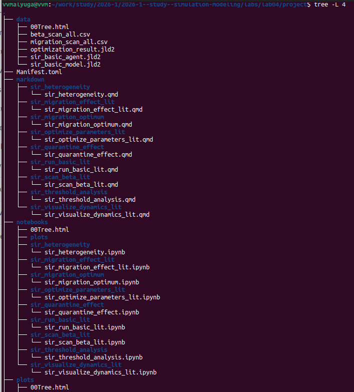

Структура каталогов проекта

*Папки data, markdown, notebooks, plots, scripts, src – всё организовано по DrWatson.*

## Выполнение лабораторной работы

### Исходный код моделей

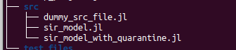

Файлы sir_model.jl и sir_model_with_quarantine.jl

## Выполнение лабораторной работы

### Базовый запуск: динамика SIR

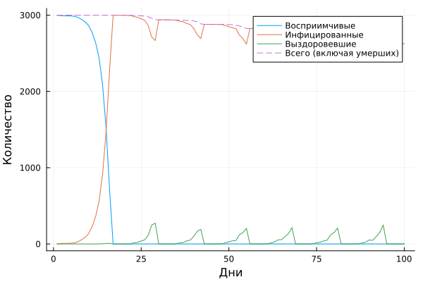

График динамики S, I, R

*Синий – восприимчивые, красный – инфицированные, зелёный – выздоровевшие. Пик заболеваемости ≈ 20-й день.*

## Выполнение лабораторной работы

### Сканирование β: таблица результатов

[figure not shown]

Фрагмент таблицы beta_scan_all.csv

*С ростом β (коэффициент передачи) увеличивается пик заболеваемости (peak).*

## Выполнение лабораторной работы

### Сканирование β: зависимость пика от β

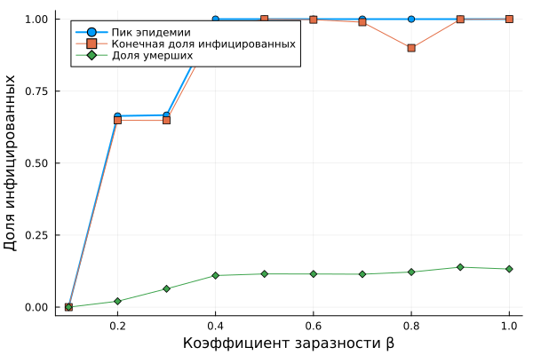

Зависимость пика заболеваемости от β

*Нелинейный рост: чем выше β, тем выше вспышка.*

## Выполнение лабораторной работы

### Эффект миграции

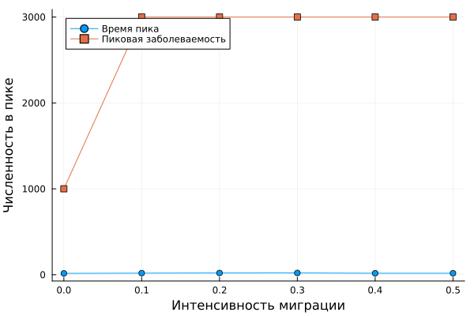

Влияние миграции на динамику эпидемии

## Выполнение лабораторной работы

### Оптимизация параметров

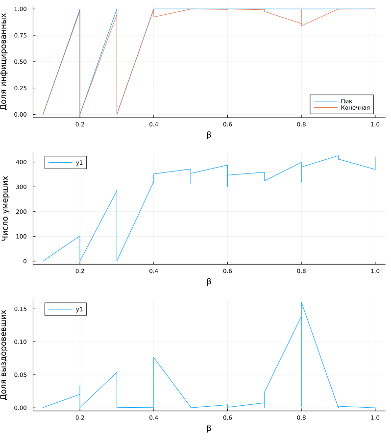

Комплексный анализ чувствительности

*Оптимальные параметры: β≈0.23, время выявления=4 дня, смертность≈0.067.*

## Выполнение лабораторной работы

### Литературное программирование

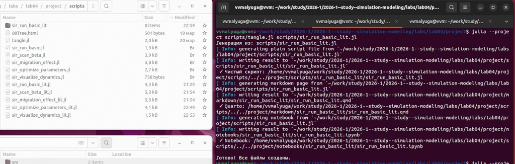

Генерация форматов через tangle.jl

*Из литературных скриптов (*_lit.jl) создаются чистый код, Jupyter Notebook и Quarto-документы.*

## Выполнение лабораторной работы

### Дополнительные задания

Выполнены четыре расширения базовой модели SIR:

- **Модель с карантином** – изоляция инфицированных.
- **Гетерогенность популяции** – возрастные группы, разная восприимчивость.
- **Пороговый анализ** – критические параметры перехода к пандемии.
- **Оптимизация миграции** – поиск оптимальной интенсивности миграции.

## Выполнение лабораторной работы

### Эффект карантина

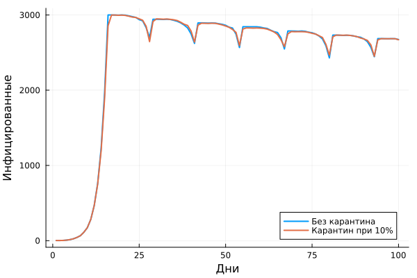

Влияние изоляции на динамику

## Выполнение лабораторной работы

### Гетерогенность популяции

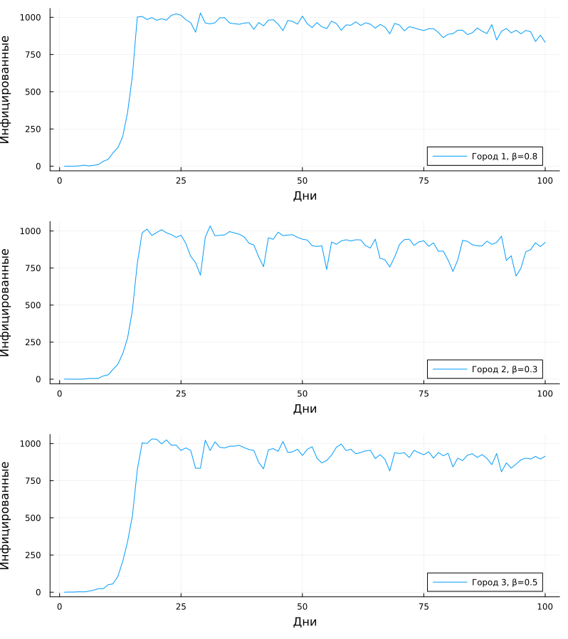

## Выполнение лабораторной работы

### Пороговый анализ

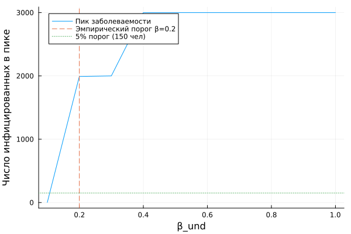

Переход от вспышки к пандемии

## Выполнение лабораторной работы

### Оптимизация миграции

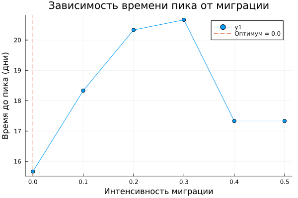

Оптимальный уровень миграции

## Выводы

1. Изучены принципы агентного моделирования.
2. Реализована модель SIR на Julia.
3. Проведены параметрические исследования.
4. Освоена технология литературного программирования (Literate.jl).
5. Выполнены дополнительные задания, расширяющие модель.

## Список литературы

Datseris, George, Ali Vahdati, и Tim Du. 2022. *Agents.jl: a Julia package for agent-based modeling*. Journal of Open Source Software.